# EarthquakeVizR Vignette

Aziiz Sutrisno

2019-11-11

## Description

The `earthquakeVizR` package is a ollection of functions to cleansed and visualize the data from the [NOAA’s Significant Earthquake dataset](https://www.ngdc.noaa.gov/nndc/struts/form?t=101650&s=1&d=1).

## Package functions

- `eq_clean_data()`
- `geom_timeline()`
- `geom_timeline_label()`
- `eq_create_label()`
- `eq_map()`

For the purposes of these examples we will use data from NOAA inside this package.

### Tidying the data

```r
raw_data <- "signif.txt"

# We use this function to fix the date and coordinates
dset <- eq_clean_data(raw_data)

# We use this function to fix the location name
dset_location <- eq_location_clean(dset)
```

**Example Result of the cleansed location, time, and the coordinates**

| LOCATION_NAME | DATE | LATITUDE | LONGITUDE |
| --- | --- | --- | --- |
| Java | 2010-01-10 | -7.907 | 107.879 |
| Off Coast Northern | 2010-01-10 | 40.652 | -124.692 |
| Port-Au-Prince | 2010-01-12 | 18.457 | -72.533 |
| Cariaco | 2010-01-15 | 10.454 | -63.475 |
| Khuzestan | 2010-01-16 | 32.450 | 48.300 |
| Guizhou Province | 2010-01-17 | 25.558 | 105.804 |
| Sichuan Province | 2010-01-30 | 30.268 | 105.668 |
| Yunnan Province | 2010-02-25 | 25.523 | 101.903 |
| Tori Shima, Okinawa | 2010-02-26 | 25.930 | 128.425 |
| Maule, Concepcion, Talcahuano | 2010-02-27 | -36.122 | -72.898 |

### Visualize earthquake timeline

We will use the following functions to visualize the earthquake timeline. We use `ggplot2` to construct the functions. First, we are using `geom_timeline` to plot the `DATE` in X-axis and `COUNTRY` in the Y-axis. Second, we pass on the `TOTAL_DEATHS` and `EQ_PRIMARY` as optional color and size.

We then use `geom_timeline_label` to pass on the `LOCATION_NAME`

Here is an example:

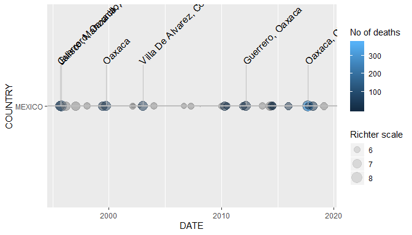

```r
dset_location %>% filter(COUNTRY == "MEXICO", YEAR > 1990) %>%
     ggplot(aes(x = DATE,
                y = COUNTRY,
                color = as.numeric(TOTAL_DEATHS),
                size = as.numeric(EQ_PRIMARY)
     )) +
     geom_timeline() +
     geom_timeline_label(aes(label = LOCATION_NAME), n_max = 5) +
     labs(size = "Richter scale", color = "No of deaths")
```

### Using Leaflet to Overlay Earthquake Data on a Map

We use `leaflet` to overlay the earthquakes data on a map. We pass on the dataset to the `eq_map` function, the map is centered around the Country location the we chose. There is an option to pass on the data label by using `eq_create_label()` function.

```r
dset_location %>%
  dplyr::filter(COUNTRY == "MEXICO" & lubridate::year(DATE) >= 2000) %>%
  dplyr::mutate(popup_text = eq_create_label(.)) %>%
  eq_map(annot_col = "popup_text")
```

[interactive chart not shown]